# Section 4.9 – Travaux Pratiques : Tests de Conformité

- Montrer tout le code
- Cacher tout le code
- Voir les sources

Auteur·rice

HAMLIL Mohamed

Date de publication

2024

# Section 4.9 – Travaux Pratiques

## Vue d’ensemble

Ce notebook présente des exercices pratiques sur les **tests de conformité** : tester si une observation ou un paramètre est conforme à une valeur de référence.

**Objectifs pédagogiques :**

- Comprendre la structure générale d’un test statistique
- Maîtriser les tests sur une seule population (moyenne, variance, proportion)
- Tester des corrélations et interpréter les p-valeurs
- Appliquer les tests dans R et interpréter les résultats

**Concepts clés :**

- **Hypothèse nulle** $H_0$ : hypothèse à tester
- **Hypothèse alternative** $H_1$ : ce qu’on affirme si $H_0$ est rejetée
- **P-valeur** : probabilité d’observer un résultat aussi extrême sous $H_0$
- **Niveau de risque** $\alpha$ : seuil de décision (ex: 5%)

## 4.9.1 Principes des Tests Statistiques

### Structure générale d’un test

Un test statistique répond à la question : “**Mes données sont-elles compatibles avec l’hypothèse H₀ ?**”

**Étapes :**

1. **Formulation** : Énoncer H₀ (hypothèse nulle) et H₁ (hypothèse alternative)
2. **Statistique de test** : Calculer une statistique à partir des données
3. **P-valeur** : Calculer la probabilité (sous H₀) d’observer une stat aussi extrême
4. **Décision** :
   - Si p-valeur < $\alpha$ : rejeter H₀ (**résultat significatif**)
   - Si p-valeur $\ge \alpha$ : ne pas rejeter H₀ (**pas de preuve contre H₀**)

**Interprétation cruciale :** Ne pas rejeter H₀ $\neq$ Accepter H₀

### Tests présentés

Dans ce notebook, nous testons l’hypothèse que un paramètre d’une population est égal à une valeur connue $\theta_0$ :

| Paramètre | Test | Fonction R | Hypothèses |
| --- | --- | --- | --- |
| Moyenne $\mu$ | t-test Student | `t.test()` | Données ~ $N(\mu,\sigma^2)$ |
| Variance $\sigma^2$ | Chi-deux | `var.test()` ou `sigma2.test()` | Données ~ $N(\mu,\sigma^2)$ |
| Proportion $p$ | Binomial/Proportion | `prop.test()` | $n$ grand ou `binom.test()` |
| Corrélation $\rho$ | Test de Pearson | `cor.test()` | Bivariée normale |

## 4.9.3 Comparaison de la Moyenne à une Valeur de Référence

### Contexte et Hypothèses

**Question :** La moyenne d’une population est-elle égale à une valeur de référence $\mu_0$ ?

**Hypothèses :**

- **H₀** : $\mu = \mu_0$ (la moyenne population égale la référence)
- **H₁** : $\mu \neq \mu_0$ (la moyenne diffère de la référence) [bilatéral]
- Ou **H₁** : $\mu > \mu_0$ ou $\mu < \mu_0$ [unilatéral]

**Test à utiliser :** **t-test de Student** (si $\sigma^2$ inconnue)

**Statistique :**
$$t = \frac{\bar{x} - \mu_0}{s/\sqrt{n}} \sim t_{n-1} \quad \text{sous } H_0$$

**Interprétation :**

- Si $|t|$ grande $\implies$ p-valeur petite $\implies$ rejeter H₀
- Si $|t|$ petite $\implies$ p-valeur grande $\implies$ garder H₀

```r
# ========= T-TEST: Comparer une moyenne à μ₀ =========

cat("\n=== T-Test de Student ===\n\n")
```

```
=== T-Test de Student ===
```

```r
# Exemple: mesures d'une variable quantitative
x <- c(0.62, 0.55, 0.58, 0.63, 0.60, 0.59, 0.57, 0.61)

# Valeur de référence
mu0 <- 0.58

cat("Données observées:\n")
```

```
Données observées:
```

```r
print(x)
```

```
[1] 0.62 0.55 0.58 0.63 0.60 0.59 0.57 0.61
```

```r
cat("\nStatistiques descriptives:\n")
```

```
Statistiques descriptives:
```

```r
cat("  Moyenne:    ", round(mean(x), 4), "\n")
```

```
  Moyenne:     0.5938
```

```r
cat("  Écart-type: ", round(sd(x), 4), "\n")
```

```
  Écart-type:  0.0267
```

```r
cat("  Taille:     ", length(x), "\n")
```

```
  Taille:      8
```

```r
cat("  Référence μ₀:", mu0, "\n\n")
```

```
  Référence μ₀: 0.58
```

```r
# === TEST UNILATÉRAL: H1 est μ > μ₀ ===
cat("=== Hypothèses ===\n")
```

```
=== Hypothèses ===
```

```r
cat("  H₀: μ = ", mu0, "(la moyenne égale la référence)\n")
```

```
  H₀: μ =  0.58 (la moyenne égale la référence)
```

```r
cat("  H₁: μ > ", mu0, "(la moyenne est supérieure)\n\n")
```

```
  H₁: μ >  0.58 (la moyenne est supérieure)
```

```r
# Effectuer le test
resultat_test <- t.test(x, mu = mu0, alternative = "greater")

# Afficher les résultats
cat("=== Résultats du Test ===\n")
```

```
=== Résultats du Test ===
```

```r
cat("  Statistique t:", round(resultat_test$statistic, 4), "\n")
```

```
  Statistique t: 1.457
```

```r
cat("  Degrés de liberté:", resultat_test$parameter, "\n")
```

```
  Degrés de liberté: 7
```

```r
cat("  P-valeur:", round(resultat_test$p.value, 4), "\n\n")
```

```
  P-valeur: 0.0942
```

```r
# Décision au niveau α = 5%
alpha <- 0.05
if (resultat_test$p.value < alpha) {
  decision <- "REJETER H₀"
  interpretation <- "La moyenne est SIGNIFICATIVEMENT supérieure à la référence"
} else {
  decision <- "NE PAS REJETER H₀"
  interpretation <- "Pas de preuve que la moyenne dépasse la référence"
}

cat("=== Décision (α = 5%) ===\n")
```

```
=== Décision (α = 5%) ===
```

```r
cat("  Décision:      ", decision, "\n")
```

```
  Décision:       NE PAS REJETER H₀
```

```r
cat("  Interprétation:", interpretation, "\n")
```

```
  Interprétation: Pas de preuve que la moyenne dépasse la référence
```

### Variante : Test Bilatéral

```r
t.test(x, mu = mu0, alternative = "two.sided")
```

Cette variante test-elle une déviation dans n’importe quelle direction (haute ou basse).

### Application Pratique

Dans le polycopié, on peut filtrer les données selon un critère (ex: IMC > 30) puis appliquer le test :

```r
IMC <- poids / ((taille/100)^2)
mesure_IMC_haut <- mesure[IMC > 30]
t.test(mesure_IMC_haut, mu = 0.58, alternative = "greater")
```

## 4.9.4 Comparaison de la Variance à une Valeur de Référence

### Contexte et Hypothèses

**Test à utiliser :** **Test du Chi-deux**

**Fonctions R disponibles :**

- `var.test()` : teste l’égalité de deux variances
- `sigma2.test()` : teste une variance contre une valeur (si le package est chargé)

```r
# ========= TEST CHI-DEUX: Comparer une variance à σ₀² =========

cat("\n=== Test de Variance (Chi-Deux) ===\n\n")
```

```
=== Test de Variance (Chi-Deux) ===
```

```r
# Exemple: poids de boîtes de conserve
poids <- c(165.1, 171.5, 168.1, 165.6, 166.8, 170.0, 168.8, 171.1, 168.8, 173.6,
           163.5, 169.9, 165.4, 174.4, 171.8, 166.0, 174.6, 174.5, 166.4, 173.8)

# Variance de référence
sigma2_0 <- 10

cat("Données observées: ", length(poids), "poids de boîtes\n")
```

```
Données observées:  20 poids de boîtes
```

```r
cat("Statistiques descriptives:\n")
```

```
Statistiques descriptives:
```

```r
cat("  Moyenne:   ", round(mean(poids), 2), "g\n")
```

```
  Moyenne:    169.49 g
```

```r
cat("  Variance:  ", round(var(poids), 4), "\n")
```

```
  Variance:   12.7392
```

```r
cat("  Écart-type:", round(sd(poids), 4), "g\n")
```

```
  Écart-type: 3.5692 g
```

```r
cat("  Référence σ₀²:", sigma2_0, "\n\n")
```

```
  Référence σ₀²: 10
```

```r
# === TEST CHI-DEUX MANUEL ===
cat("=== Hypothèses ===\n")
```

```
=== Hypothèses ===
```

```r
cat("  H₀: σ² = ", sigma2_0, "(variance égale la référence)\n")
```

```
  H₀: σ² =  10 (variance égale la référence)
```

```r
cat("  H₁: σ² ≠ ", sigma2_0, "(variance diffère) [bilatéral]\n\n")
```

```
  H₁: σ² ≠  10 (variance diffère) [bilatéral]
```

```r
# Calculer la statistique
n <- length(poids)
df_lib <- n - 1  # Degrés de liberté
chi2_obs <- df_lib * var(poids) / sigma2_0

# Calculer la p-valeur bilatérale
p_val_inf <- pchisq(chi2_obs, df = df_lib)  # P(χ² < χ²_obs)
p_val_sup <- 1 - p_val_inf                   # P(χ² > χ²_obs)
p_val_bilat <- 2 * min(p_val_inf, p_val_sup)  # Bilatéral

cat("=== Résultats du Test ===\n")
```

```
=== Résultats du Test ===
```

```r
cat("  Statistique χ²:", round(chi2_obs, 4), "\n")
```

```
  Statistique χ²: 24.2046
```

```r
cat("  Degrés de liberté:", df_lib, "\n")
```

```
  Degrés de liberté: 19
```

```r
cat("  P-valeur (bilatérale):", round(p_val_bilat, 4), "\n\n")
```

```
  P-valeur (bilatérale): 0.3768
```

```r
# Décision au niveau α = 5%
alpha <- 0.05
if (p_val_bilat < alpha) {
  decision <- "REJETER H₀"
  interpretation <- "La variance EST SIGNIFICATIVEMENT différente de la référence"
} else {
  decision <- "NE PAS REJETER H₀"
  interpretation <- "Pas de preuve que la variance diffère de la référence"
}

cat("=== Décision (α = 5%) ===\n")
```

```
=== Décision (α = 5%) ===
```

```r
cat("  Décision:      ", decision, "\n")
```

```
  Décision:       NE PAS REJETER H₀
```

```r
cat("  Interprétation:", interpretation, "\n")
```

```
  Interprétation: Pas de preuve que la variance diffère de la référence
```

Il existe des fonctions dédiées telles que `sigma2.test()` du package **sigma2tools**. Si le package est installé, on peut appeler :

```r
# install.packages("sigma2tools")
library(sigma2tools)
sigma2.test(poids, var0 = 10)
```

Ce test retourne directement la statistique de test, les degrés de liberté et la p‑valeur.

```r
# Note : Ce bloc est désactivé (eval: false) car il dépend d'un fichier local "TP3/..."
# Si vous avez le fichier, changez en eval: true

# Load sigma2.test function from the local file
source("TP3/post-199979-sigma2.test.R")

# Example usage with the poids data from above
sigma2.test(poids, var0 = 10)
```

## 4.9.5 Comparaison d’une Proportion à une Valeur de Référence

### Contexte et Hypothèses

```r
# ========= TEST DE PROPORTION =========

cat("\n=== Test de Proportion ===\n\n")
```

```
=== Test de Proportion ===
```

```r
# Exemple: épidémiologie
# Nombre de cas observés et taille de l'échantillon
x <- 10   # Nombre de succès (cas)
n <- 147  # Taille totale
p0 <- 0.1 # Proportion théorique (10%)

cat("Contexte: Infection chez femmes ≤ 25 ans\n")
```

```
Contexte: Infection chez femmes ≤ 25 ans
```

```r
cat("  Cas observés (x):", x, "\n")
```

```
  Cas observés (x): 10
```

```r
cat("  Taille (n):     ", n, "\n")
```

```
  Taille (n):      147
```

```r
cat("  Proportion observée:", round(x/n, 4), "\n")
```

```
  Proportion observée: 0.068
```

```r
cat("  Proportion référence (p₀):", p0, "\n\n")
```

```
  Proportion référence (p₀): 0.1
```

```r
# === TEST: H1 est p < p₀ (unilatéral inférieur) ===
cat("=== Hypothèses ===\n")
```

```
=== Hypothèses ===
```

```r
cat("  H₀: p = ", p0, "(la proportion égale la référence)\n")
```

```
  H₀: p =  0.1 (la proportion égale la référence)
```

```r
cat("  H₁: p < ", p0, "(la proportion est INFÉRIEURE) [unilatéral]\n\n")
```

```
  H₁: p <  0.1 (la proportion est INFÉRIEURE) [unilatéral]
```

```r
# Effectuer le test
test_prop <- prop.test(x, n, p = p0, alternative = "less", correct = FALSE)

cat("=== Résultats du Test ===\n")
```

```
=== Résultats du Test ===
```

```r
cat("  Statistique χ²:", round(test_prop$statistic, 4), "\n")
```

```
  Statistique χ²: 1.6697
```

```r
cat("  P-valeur:     ", round(test_prop$p.value, 4), "\n")
```

```
  P-valeur:      0.0982
```

```r
cat("  IC 95%:        [", round(test_prop$conf.int[1], 4),
    ";", round(test_prop$conf.int[2], 4), "]\n\n")
```

```
  IC 95%:        [ 0 ; 0.1106 ]
```

```r
# Décision au niveau α = 5%
alpha <- 0.05
if (test_prop$p.value < alpha) {
  decision <- "REJETER H₀"
  interpretation <- "La proportion EST SIGNIFICATIVEMENT inférieure à 10%"
} else {
  decision <- "NE PAS REJETER H₀"
  interpretation <- "Pas de preuve que la proportion soit < 10%"
}

cat("=== Décision (α = 5%) ===\n")
```

```
=== Décision (α = 5%) ===
```

```r
cat("  Décision:      ", decision, "\n")
```

```
  Décision:       NE PAS REJETER H₀
```

```r
cat("  Interprétation:", interpretation, "\n")
```

```
  Interprétation: Pas de preuve que la proportion soit < 10%
```

Ici, `correct = FALSE` supprime la correction de continuité (cas des grands échantillons). Pour les petits échantillons, on peut utiliser `binom.test()` qui calcule une p‑valeur exacte basée sur la loi binomiale.

## 4.9.6 Test d’un Coefficient de Corrélation

### Contexte et Hypothèses

**Question :** Existe-t-il une corrélation linéaire significative entre deux variables X et Y ?

**Test à utiliser :** **Test de corrélation de Pearson**

```r
# ========= TEST DE CORRÉLATION =========

cat("\n=== Test de Corrélation de Pearson ===\n\n")
```

```
=== Test de Corrélation de Pearson ===
```

```r
# Générer deux variables corrélées
set.seed(42)
n_obs <- 30
X <- rnorm(n_obs)
Y <- 0.7 * X + rnorm(n_obs, sd = 0.5)  # Y dépend de X

cat("Données: ", n_obs, "paires (X, Y)\n")
```

```
Données:  30 paires (X, Y)
```

```r
cat("Corrélation simulée forte (Y = 0.7*X + bruit)\n\n")
```

```
Corrélation simulée forte (Y = 0.7*X + bruit)
```

```r
# Calculer la corrélation empirique
r_obs <- cor(X, Y)

cat("=== Hypothèses ===\n")
```

```
=== Hypothèses ===
```

```r
cat("  H₀: ρ = 0 (pas de corrélation linéaire)\n")
```

```
  H₀: ρ = 0 (pas de corrélation linéaire)
```

```r
cat("  H₁: ρ ≠ 0 (corrélation existe) [bilatéral]\n\n")
```

```
  H₁: ρ ≠ 0 (corrélation existe) [bilatéral]
```

```r
# Effectuer le test
test_cor <- cor.test(X, Y, alternative = "two.sided")

cat("=== Résultats du Test ===\n")
```

```
=== Résultats du Test ===
```

```r
cat("  Coefficient r (Pearson):", round(r_obs, 4), "\n")
```

```
  Coefficient r (Pearson): 0.8322
```

```r
cat("  Statistique t:          ", round(test_cor$statistic, 4), "\n")
```

```
  Statistique t:           7.9417
```

```r
cat("  Degrés de liberté:      ", test_cor$parameter, "\n")
```

```
  Degrés de liberté:       28
```

```r
cat("  P-valeur:               ", round(test_cor$p.value, 6), "\n")
```

```
  P-valeur:                0
```

```r
cat("  IC 95%:                 [", round(test_cor$conf.int[1], 4),
    ";", round(test_cor$conf.int[2], 4), "]\n\n")
```

```
  IC 95%:                 [ 0.674 ; 0.9174 ]
```

```r
# Décision au niveau α = 5%
alpha <- 0.05
if (test_cor$p.value < alpha) {
  decision <- "REJETER H₀"
  interpretation <- paste("Corrélation SIGNIFICATIVE (r =", round(r_obs, 4), ")")
} else {
  decision <- "NE PAS REJETER H₀"
  interpretation <- "Pas de preuve de corrélation linéaire"
}

cat("=== Décision (α = 5%) ===\n")
```

```
=== Décision (α = 5%) ===
```

```r
cat("  Décision:      ", decision, "\n")
```

```
  Décision:       REJETER H₀
```

```r
cat("  Interprétation:", interpretation, "\n\n")
```

```
  Interprétation: Corrélation SIGNIFICATIVE (r = 0.8322 )
```

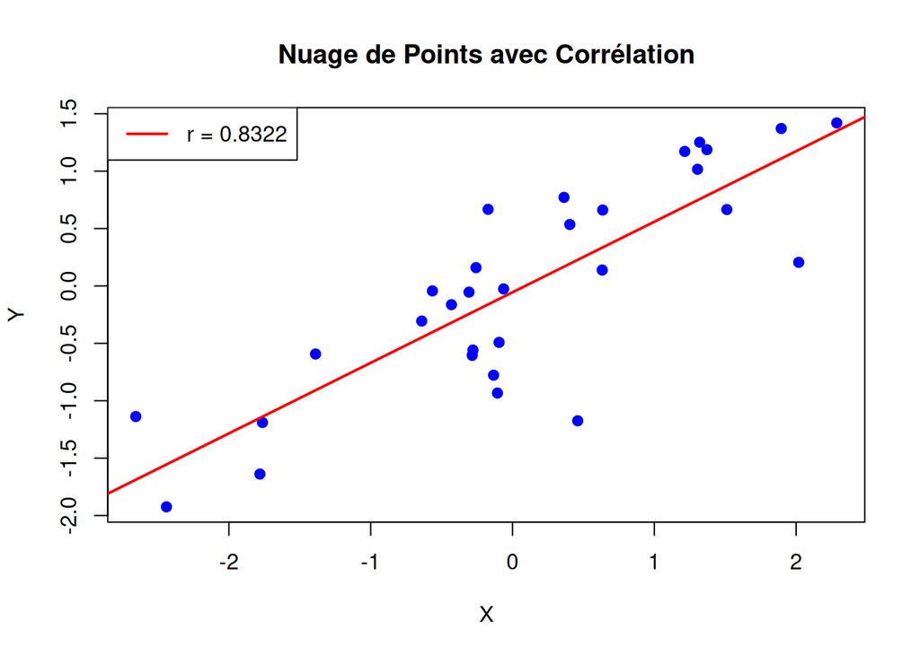

```r
# Visualiser la corrélation
plot(X, Y, main = "Nuage de Points avec Corrélation",
     xlab = "X", ylab = "Y", pch = 19, col = "blue")
abline(lm(Y ~ X), col = "red", lwd = 2)  # Droite de régression
legend("topleft", legend = paste("r =", round(r_obs, 4)),
       col = "red", lwd = 2)
```

Si on souhaite tester un coefficient différent de 0, on peut utiliser la transformation de Fisher (fonctions disponibles dans certains packages comme **LeLogicielR**). Dans de nombreux cas pratiques, la fonction `cor.test()` suffit.

## 📌 Résumé et Points Clés

### Fonctions R Utilisées

| Test | Fonction | Syntaxe |
| --- | --- | --- |
| Moyenne | `t.test()` | `t.test(x, mu = μ0, alternative = "...")` |
| Variance | `var.test()` | Compare deux variances |
| Proportion | `prop.test()` | `prop.test(x, n, p = p0, alternative = "...")` |
| Corrélation | `cor.test()` | `cor.test(X, Y, alternative = "two.sided")` |

### Bonnes Pratiques

- ✅ **Vérifier les hypothèses** du test avant de l’appliquer
- ✅ **Choisir la direction** de l’alternative avant de voir les données (unilatéral vs. bilatéral)
- ✅ **Reporter aussi l’intervalle de confiance**, pas juste la p-valeur
- ✅ **Ne pas interpréter** « ne pas rejeter H₀ » comme « accepter H₀ »
- ✅ **Taille d’effet** : regarder aussi l’amplitude des différences, pas juste la significativité

### Pièges Courants

- ❌ Chercher le test qui donne la p-valeur la plus petite
- ❌ Ignorer les hypothèses du test (normalité, indépendance, etc.)
- ❌ Interpréter p > 0.05 comme “H₀ est vraie”
- ❌ Multiplier les tests sans correction (risque d’erreur augmente)
- ❌ Confondre significativité statistique et significativité pratique